# K-means clustering and PCA

Unnikrishnan

## K-means clustering

#### HARTIGAN is a dataset directory that contains test data for clustering algorithms. The data files are all simple text files, and the format of the data files is explained on the web page at https://people.sc.fsu.edu/~jburkardt/datasets/hartigan/hartigan.html Perform K-means clustering on file19.txt on the above web page. This file contains a multivariate mammals dataset; there are 9 columns and 66 rows.

```r
options(digits=4)
df.km = read.table("file19.txt",skip=20,header = T)
df.km
```

| Name | I | i | C | c | P | p | M | m |
| --- | --- | --- | --- | --- | --- | --- | --- | --- |
| Opossum | 5 | 4 | 1 | 1 | 3 | 3 | 4 | 4 |
| Hairy tail mole | 3 | 3 | 1 | 1 | 4 | 4 | 3 | 3 |
| Common mole | 3 | 2 | 1 | 0 | 3 | 3 | 3 | 3 |
| Star nose mole | 3 | 3 | 1 | 1 | 4 | 4 | 3 | 3 |
| Brown bat | 2 | 3 | 1 | 1 | 3 | 3 | 3 | 3 |
| Silver hair bat | 2 | 3 | 1 | 1 | 2 | 3 | 3 | 3 |
| Pigmy bat | 2 | 3 | 1 | 1 | 2 | 2 | 3 | 3 |
| House bat | 2 | 3 | 1 | 1 | 1 | 2 | 3 | 3 |
| Red bat | 1 | 3 | 1 | 1 | 2 | 2 | 3 | 3 |
| Hoary bat | 1 | 3 | 1 | 1 | 2 | 2 | 3 | 3 |

[output cut: 56 more lines]

### Think of what attributes, if any, you may want to omit from the dataset when you do the clustering. Indicate all of the attributes you removed before doing the clustering.

### By seeing the correlation between the attributes,C&c,P&p,M&m are highly correlated pairs(above 90%).Similarly I&C,I&c,C&P,C&p,I&p,I&P are also correlated pairs.We can eliminate the one of the attributes among those highly correlate pairs(C&c,P&p,M&m) mentioned above before attempting clustering because it is like a repetition of feature/attribute.Actual method is whiten (decorrelate) the data by doing PCA, which is a best practise for k-means.Here I have created a data set after removing one of highly correlated attributes.The removed attributes are c,p and m.The remaining attributes used are I,i,C,P and M.The new data set is df.km.mod.

```r
df.km.cor <- cor(df.km[2:9])
df.km.cor
```

```
        I       i       C       c       P       p       M       m
I  1.0000  0.1659  0.7208  0.7737  0.5013  0.4741 -0.5321 -0.4277
i  0.1659  1.0000  0.4610  0.3795  0.5990  0.6640 -0.1861 -0.1291
C  0.7208  0.4610  1.0000  0.9115  0.6414  0.6981 -0.5254 -0.4523
c  0.7737  0.3795  0.9115  1.0000  0.6001  0.6475 -0.5618 -0.4795
P  0.5013  0.5990  0.6414  0.6001  1.0000  0.9320 -0.5293 -0.4666
p  0.4741  0.6640  0.6981  0.6475  0.9320  1.0000 -0.4559 -0.3802
M -0.5321 -0.1861 -0.5254 -0.5618 -0.5293 -0.4559  1.0000  0.9327
m -0.4277 -0.1291 -0.4523 -0.4795 -0.4666 -0.3802  0.9327  1.0000
```

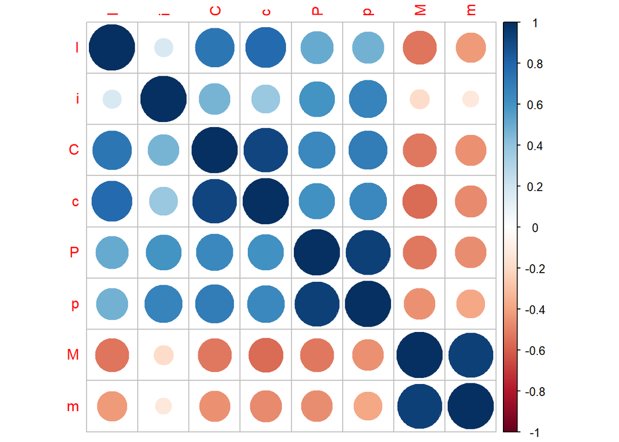

```r
library('corrplot')
corrplot(df.km.cor)
```

```r
df.km.mod <- df.km[,c("Name","I","i","C","P","M")]
```

### Does the data need to be standardized?

### The data in file19.txt is about the is tooth pattern, the number of top incisors, bottom incisors, top canines, bottom canines,top premolars, bottom premolars, top molars, and bottom molars.The unit of the measurement is same,number of teeth.So we do not need to standardize the attributes because all attributes have same unit.But always it is safe to standardize the data.

### You will have to clean the data to remove multiple spaces and make the comma character the delimiter.Please make sure you include your cleaned dataset in the archive file you upload.

### Data cleanup is done below.The file will be attached in the hw3 folder.The file name is file19output.txt.

```r
write.table(df.km, file = "file19output.txt", sep = ",",row.names=FALSE)
file.show("file19output.txt")
```

### Determine how many clusters are needed by running the WSS or Silhouette graph. Plot the graph using fviz_nbclust().

### Slope goes near to zero at k=2/3,but it again changes then goes near to zero again at k=7 onwards,which seems stable afterwards.So I would select the k=7 for all datasets df.km and df.km.mod.

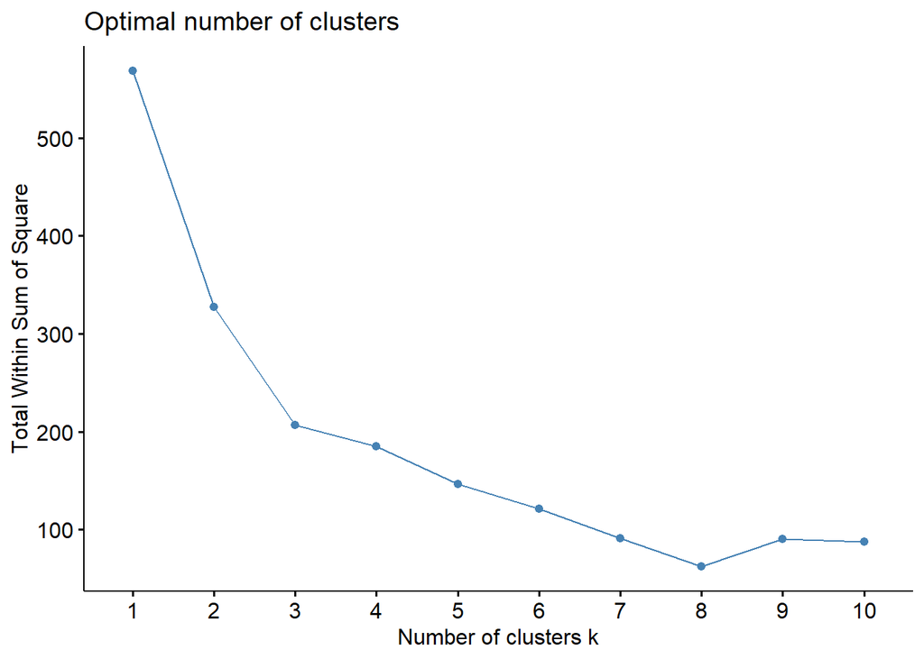

```r
library(cluster)
library(factoextra)
fviz_nbclust(df.km[2:9], kmeans, method="wss")
```

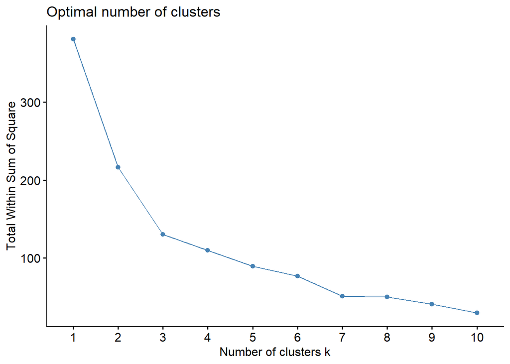

```r
fviz_nbclust(df.km.mod[2:6], kmeans, method="wss")
```

### Once you have determined the number of clusters, run k-means clustering on the dataset to create that many clusters. Plot the clusters using fviz_cluster().

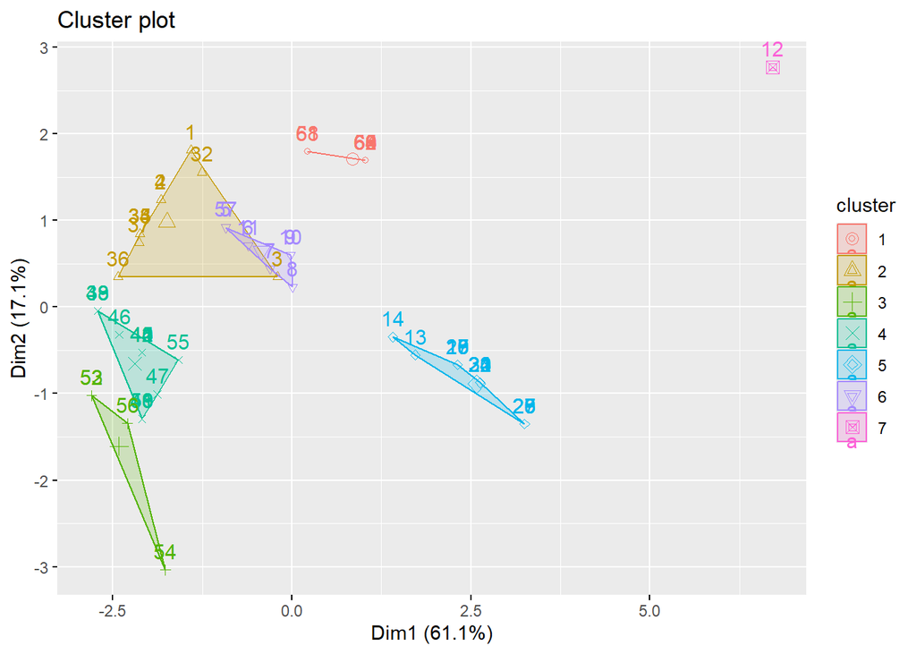

```r
k.df.km <- kmeans(df.km[2:9], centers=7, nstart=25)
fviz_cluster(k.df.km, data=df.km[2:9])
```

```r
print(k.df.km)
```

```
K-means clustering with 7 clusters of sizes 9, 10, 4, 15, 19, 8, 1

Cluster means:
      I     i      C   c     P      p     M     m
1 0.000 4.000 0.2222 0.0 3.000 3.0000 3.000 3.000
2 3.000 3.000 1.0000 0.9 3.800 3.8000 2.700 2.900
3 2.250 1.250 1.0000 1.0 3.750 3.7500 0.750 0.750
4 3.000 2.867 1.0000 1.0 3.267 2.9333 1.067 1.733
5 1.105 1.000 0.0000 0.0 1.211 0.8421 3.000 3.000
6 1.750 3.000 1.0000 1.0 2.125 2.5000 3.000 3.000
7 0.000 0.000 0.0000 0.0 0.000 0.0000 8.000 8.000

Clustering vector:
 [1] 2 2 2 2 6 6 6 6 6 6 6 7 5 5 5 5 5 5 5 5 5 5 5 5 5 5 5 5 5 5 5 2 2 2 2 2 2 4 4 4 4 4 4 4 4
[46] 4 4 4 4 4 4 3 3 3 4 3 6 1 1 1 1 1 1 1 1 1

Within cluster sum of squares by cluster:
[1]  1.556 21.100  8.500 15.467 23.474  6.375  0.000
 (between_SS / total_SS =  86.5 %)

Available components:

[1] "cluster"      "centers"      "totss"        "withinss"     "tot.withinss" "betweenss"
[7] "size"         "iter"         "ifault"
```

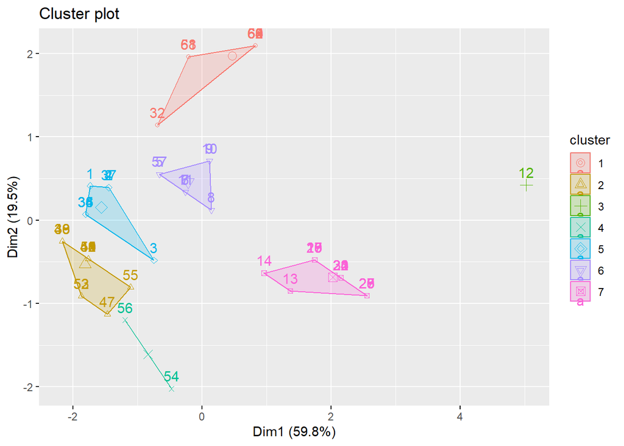

```r
##Selected dataset
k.df.km.mod <- kmeans(df.km.mod[2:6], centers=7, nstart=25)
fviz_cluster(k.df.km.mod, data=df.km.mod[2:6])
```

```r
print(k.df.km.mod)
```

```
K-means clustering with 7 clusters of sizes 10, 17, 1, 2, 9, 8, 19

Cluster means:
      I     i   C     P     M
1 0.100 3.900 0.3 3.100 3.000
2 3.000 2.765 1.0 3.353 1.059
3 0.000 0.000 0.0 0.000 8.000
4 1.500 0.500 1.0 3.500 0.500
5 3.222 3.000 1.0 3.778 2.667
6 1.750 3.000 1.0 2.125 3.000
7 1.105 1.000 0.0 1.211 3.000

Clustering vector:
 [1] 5 5 5 5 6 6 6 6 6 6 6 3 7 7 7 7 7 7 7 7 7 7 7 7 7 7 7 7 7 7 7 1 5 5 5 5 5 2 2 2 2 2 2 2 2
[46] 2 2 2 2 2 2 2 2 4 2 4 6 1 1 1 1 1 1 1 1 1

Within cluster sum of squares by cluster:
[1]  4.800  7.882  0.000  2.000 11.111  4.375 16.947
 (between_SS / total_SS =  87.6 %)

Available components:

[1] "cluster"      "centers"      "totss"        "withinss"     "tot.withinss" "betweenss"
[7] "size"         "iter"         "ifault"
```

### How many observations are in each cluster?

```r
print(k.df.km.mod)
```

```
K-means clustering with 7 clusters of sizes 10, 17, 1, 2, 9, 8, 19

Cluster means:
      I     i   C     P     M
1 0.100 3.900 0.3 3.100 3.000
2 3.000 2.765 1.0 3.353 1.059
3 0.000 0.000 0.0 0.000 8.000
4 1.500 0.500 1.0 3.500 0.500
5 3.222 3.000 1.0 3.778 2.667
6 1.750 3.000 1.0 2.125 3.000
7 1.105 1.000 0.0 1.211 3.000

Clustering vector:
 [1] 5 5 5 5 6 6 6 6 6 6 6 3 7 7 7 7 7 7 7 7 7 7 7 7 7 7 7 7 7 7 7 1 5 5 5 5 5 2 2 2 2 2 2 2 2
[46] 2 2 2 2 2 2 2 2 4 2 4 6 1 1 1 1 1 1 1 1 1

Within cluster sum of squares by cluster:
[1]  4.800  7.882  0.000  2.000 11.111  4.375 16.947
 (between_SS / total_SS =  87.6 %)

Available components:

[1] "cluster"      "centers"      "totss"        "withinss"     "tot.withinss" "betweenss"
[7] "size"         "iter"         "ifault"
```

### What is the total SSE of the clusters?

### K Here totss = tot.withinss + betweenss.Total SSE for clusters is 380.5455, which is sum of total with in SS and between SS.Where total within SS is 47.11583.

```r
print(k.df.km.mod$totss)
```

```
[1] 380.5
```

```r
print(k.df.km.mod$tot.withinss)
```

```
[1] 47.12
```

### What is the SSE of each cluster?

```r
print(k.df.km.mod$withinss)
```

```
[1]  4.800  7.882  0.000  2.000 11.111  4.375 16.947
```

### Cluster 7:Total of 19 records with i,C,M are constants.Attribute ‘I’ have variation but the least.

```r
c <- which(k.df.km.mod$cluster==1)
df.km.mod[c,]
```

|  | Name | I | i | C | P | M |
| --- | --- | --- | --- | --- | --- | --- |
| 32 | Coyote | 1 | 3 | 1 | 4 | 3 |
| 58 | Elk | 0 | 4 | 1 | 3 | 3 |
| 59 | Deer | 0 | 4 | 0 | 3 | 3 |
| 60 | Moose | 0 | 4 | 0 | 3 | 3 |
| 61 | Reindeer | 0 | 4 | 1 | 3 | 3 |
| 62 | Antelope | 0 | 4 | 0 | 3 | 3 |
| 63 | Bison | 0 | 4 | 0 | 3 | 3 |
| 64 | Mountain goat | 0 | 4 | 0 | 3 | 3 |
| 65 | Musk ox | 0 | 4 | 0 | 3 | 3 |
| 66 | Mountain sheep | 0 | 4 | 0 | 3 | 3 |

```r
rm(c)
c <- which(k.df.km.mod$cluster==2)
df.km.mod[c,]
```

|  | Name | I | i | C | P | M |
| --- | --- | --- | --- | --- | --- | --- |
| 38 | Marten | 3 | 3 | 1 | 4 | 1 |
| 39 | Fisher | 3 | 3 | 1 | 4 | 1 |
| 40 | Weasel | 3 | 3 | 1 | 3 | 1 |
| 41 | Mink | 3 | 3 | 1 | 3 | 1 |
| 42 | Ferrer | 3 | 3 | 1 | 3 | 1 |
| 43 | Wolverine | 3 | 3 | 1 | 4 | 1 |
| 44 | Badger | 3 | 3 | 1 | 3 | 1 |
| 45 | Skunk | 3 | 3 | 1 | 3 | 1 |
| 46 | River otter | 3 | 3 | 1 | 4 | 1 |
| 47 | Sea otter | 3 | 2 | 1 | 3 | 1 |

[output cut: 7 more lines]

```r
rm(c)
c <- which(k.df.km.mod$cluster==3)
df.km.mod[c,]
```

|  | Name | I | i | C | P | M |
| --- | --- | --- | --- | --- | --- | --- |
| 12 | Armadillo | 0 | 0 | 0 | 0 | 8 |

```r
rm(c)
c <- which(k.df.km.mod$cluster==4)
df.km.mod[c,]
```

|  | Name | I | i | C | P | M |
| --- | --- | --- | --- | --- | --- | --- |
| 54 | Walrus | 1 | 0 | 1 | 3 | 0 |
| 56 | Elephant seal | 2 | 1 | 1 | 4 | 1 |

```r
rm(c)
c <- which(k.df.km.mod$cluster==5)
df.km.mod[c,]
```

|  | Name | I | i | C | P | M |
| --- | --- | --- | --- | --- | --- | --- |
| 1 | Opossum | 5 | 4 | 1 | 3 | 4 |
| 2 | Hairy tail mole | 3 | 3 | 1 | 4 | 3 |
| 3 | Common mole | 3 | 2 | 1 | 3 | 3 |
| 4 | Star nose mole | 3 | 3 | 1 | 4 | 3 |
| 33 | Wolf | 3 | 3 | 1 | 4 | 2 |
| 34 | Fox | 3 | 3 | 1 | 4 | 2 |
| 35 | Bear | 3 | 3 | 1 | 4 | 2 |
| 36 | Civet cat | 3 | 3 | 1 | 4 | 2 |
| 37 | Raccoon | 3 | 3 | 1 | 4 | 3 |

```r
rm(c)
c <- which(k.df.km.mod$cluster==6)
df.km.mod[c,]
```

|  | Name | I | i | C | P | M |
| --- | --- | --- | --- | --- | --- | --- |
| 5 | Brown bat | 2 | 3 | 1 | 3 | 3 |
| 6 | Silver hair bat | 2 | 3 | 1 | 2 | 3 |
| 7 | Pigmy bat | 2 | 3 | 1 | 2 | 3 |
| 8 | House bat | 2 | 3 | 1 | 1 | 3 |
| 9 | Red bat | 1 | 3 | 1 | 2 | 3 |
| 10 | Hoary bat | 1 | 3 | 1 | 2 | 3 |
| 11 | Lump nose bat | 2 | 3 | 1 | 2 | 3 |
| 57 | Peccary | 2 | 3 | 1 | 3 | 3 |

```r
rm(c)
c <- which(k.df.km.mod$cluster==7)
df.km.mod[c,]
```

|  | Name | I | i | C | P | M |
| --- | --- | --- | --- | --- | --- | --- |
| 13 | Pika | 2 | 1 | 0 | 2 | 3 |
| 14 | Snowshoe rabbit | 2 | 1 | 0 | 3 | 3 |
| 15 | Beaver | 1 | 1 | 0 | 2 | 3 |
| 16 | Marmot | 1 | 1 | 0 | 2 | 3 |
| 17 | Groundhog | 1 | 1 | 0 | 2 | 3 |
| 18 | Prairie Dog | 1 | 1 | 0 | 2 | 3 |
| 19 | Ground Squirrel | 1 | 1 | 0 | 2 | 3 |
| 20 | Chipmunk | 1 | 1 | 0 | 2 | 3 |
| 21 | Gray squirrel | 1 | 1 | 0 | 1 | 3 |
| 22 | Fox squirrel | 1 | 1 | 0 | 1 | 3 |

[output cut: 9 more lines]

```r
rm(c)
```

## Hierarchical clustering

### For this problem, you will use the “Languages spoken in Europe” dataset available from the Hartigan datasets.This dataset is available at https://people.sc.fsu.edu/~jburkardt/datasets/hartigan/file46.txt. Read this file into R.Note that you will have to pre-process the file since it is not, strictly speaking, a CSV file. Also make sure that the first column is recognized as a row label. (Hint: See the help on read.csv() and look at the row.names parameter.) Recognizing the first column as a row label is important because we want the country names to be printed as labels in the dendograms.

```r
df.hc = read.table("file46.txt",skip=17,header = T)
rownames(df.hc) <- df.hc[,1]
df.hc[,1] <- NULL
df.hc
```

|  | FI | SW | DA | NO | EN | GE | DU | FL | FR | IT | SP | PO |
| --- | --- | --- | --- | --- | --- | --- | --- | --- | --- | --- | --- | --- |
| West Germany | 0 | 0 | 0 | 0 | 21 | 100 | 2 | 1 | 10 | 2 | 1 | 0 |
| Italy | 0 | 0 | 0 | 0 | 5 | 3 | 0 | 0 | 11 | 100 | 1 | 0 |
| France | 0 | 2 | 3 | 0 | 10 | 7 | 1 | 1 | 100 | 12 | 7 | 1 |
| Netherlands | 0 | 0 | 0 | 0 | 41 | 47 | 100 | 100 | 16 | 2 | 2 | 0 |
| Belgium | 0 | 0 | 0 | 0 | 14 | 15 | 0 | 59 | 44 | 2 | 1 | 0 |
| Luxemburg | 0 | 0 | 0 | 0 | 31 | 100 | 4 | 1 | 92 | 10 | 0 | 0 |
| Great Britain | 0 | 0 | 0 | 0 | 100 | 7 | 0 | 0 | 15 | 3 | 2 | 0 |
| Portugal | 0 | 0 | 0 | 0 | 9 | 0 | 0 | 0 | 10 | 1 | 2 | 100 |
| Austria | 0 | 0 | 0 | 0 | 18 | 100 | 1 | 1 | 4 | 2 | 1 | 0 |
| Switzerland | 0 | 0 | 0 | 0 | 21 | 83 | 1 | 2 | 64 | 23 | 3 | 1 |

[output cut: 6 more lines]

### Run hierarchical clustering on the dataset using factoextra::eclust() method. Run the clustering algorithm for three linkages: single, complete, and average. Plot the dendogram associated with each linkage using fviz_dend(). Make sure that the labels (country names) are visible at the leafs of the dendogram.

### k(the number of clusters to be generated) is taken as three in all of the linkages.

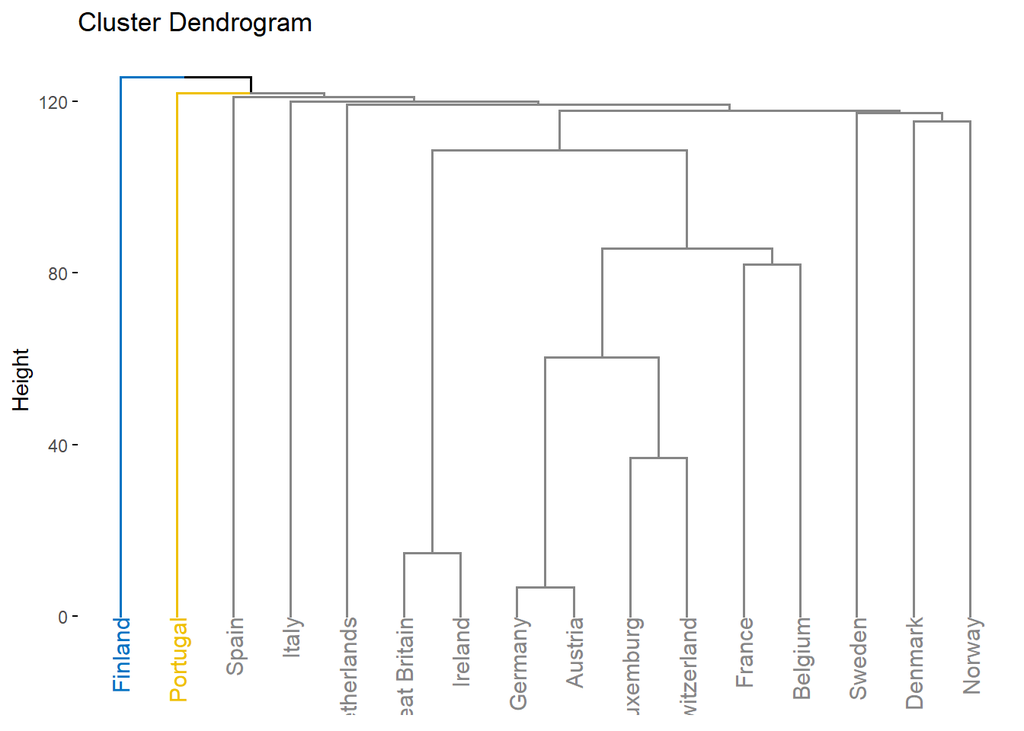

```r
hr.single <- eclust(df.hc, "hclust", k = 3, hc_method="single")
fviz_dend(hr.single, show_labels=TRUE, palette="jco", as.ggplot=T)
```

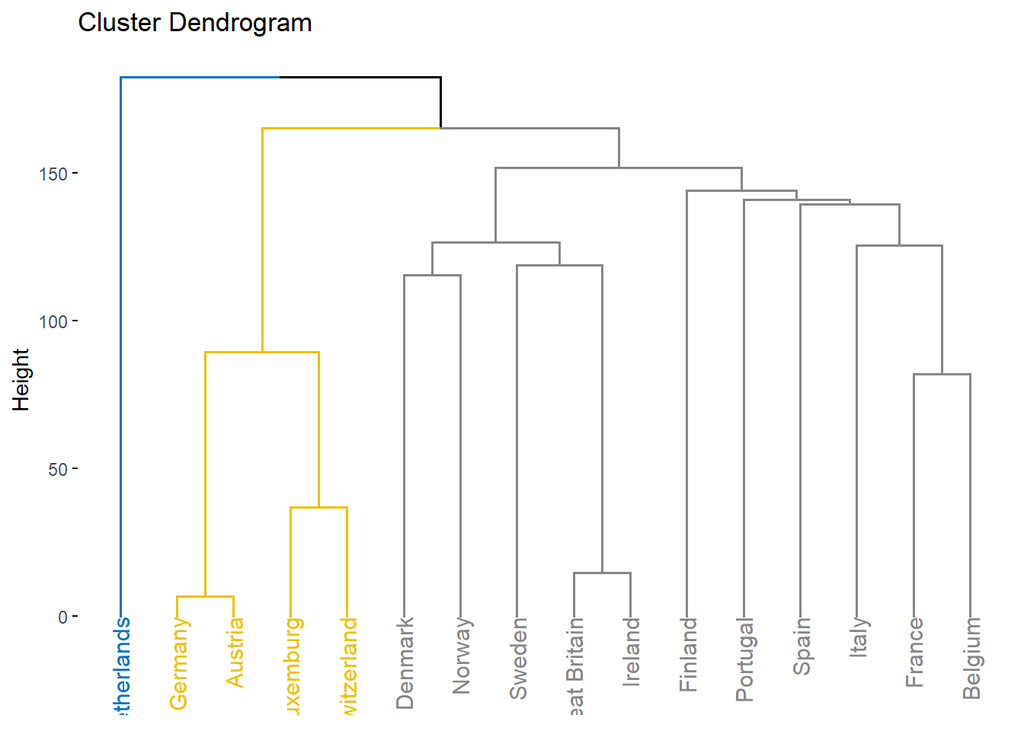

```r
hr.complete <- eclust(df.hc, "hclust", k = 3, hc_method="complete")
fviz_dend(hr.complete, show_labels=TRUE, palette="jco", as.ggplot=T)
```

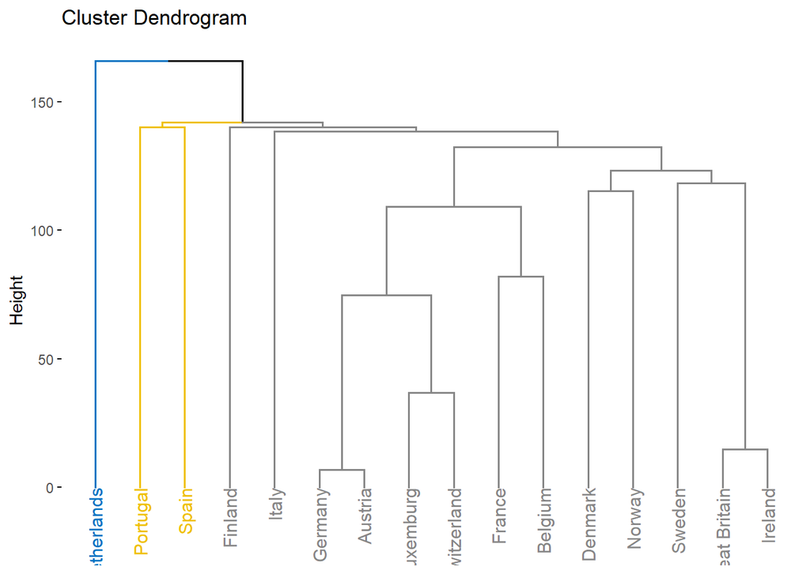

```r
hr.average <- eclust(df.hc, "hclust", k = 3, hc_method="average")
fviz_dend(hr.average, show_labels=TRUE, palette="jco", as.ggplot=T)
```

### Examine each graph produced in (a) and understand the dendrogram. Notice which countries are clustered together as two-singleton clusters (i.e., two countries clustered together because they are very close to each other in the shared languages/s). For each linkage method, list all the two singleton clusters. For instance, {Great Britain, Ireland} form a two-singleton cluster since they share English as a common language.

### Method of single linkage or nearest neighbour: Proximity between two clusters is the proximity between their two closest objects.All the two singleton clusters : {Great britain,Ireland},{Luxemburg,Switzerland},{Germany,Austria},{France,Belgium},{Denmark,Norway}

### Method of complete linkage or farthest neighbour: Proximity between two clusters is the proximity between their two most distant objects.All the two singleton clusters : {Great britain,Ireland},{Luxemburg,Switzerland},{Germany,Austria},{France,Belgium},{Denmark,Norway}

### Method of average .Proximity between two clusters is the arithmetic mean of all the proximities between the objects of one, on one side, and the objects of the other, on the other side.All the two singleton clusters : {Great britain,Ireland},{Luxemburg,Switzerland},{Germany,Austria},{France,Belgium},{Denmark,Norway},{Portugal,Spain}

### Interpretation : For example in first dendogram the cluster containing denmark and norway is merged with sweden because the distance between that cluster from sweden is calculated using MIN proximity measure.Where as the same pair denmark and norway is merged with another cluster,where sweden is merged with cluster containing great britain and ireland.These changes happens in dendogram due to the changes in proximity calculation.Regardless of the proximity measures,for example {Germany,Austria} remains same in all three linkages, because of the LEAST distance between them.They are selected to merge at initial stage only due to the minimum dist between them.We have to select a linkage strategy according to what makes sense to our domain need.We can not say which is good which is bad.

### Italy is clustered with a larger cluster in the single and average linkage, whereas in complete linkage it is clustered with a smaller cluster. Which linkage strategy do you think accurately reflects how Italy should be clustered? (Hint: Look at the raw data.) Justify your answer in 1-2 sentences.

### In complete linkage Italy is merged with a cluster of France and Belgium.France and Belgium is two-singleton cluster, due to the reason that France and Belgium have a good percentage who speaks FR(am just using the code name here).In Italy majority speaks IT, but FR is only 11 percent, which is no way near to the statistics of what France and Belgium have in common(FR percentage is high).In my intuition we can not comment on the linkage strategy,just select the ones which makes sense.Actually Italy have to be paired to some branch which has Switzerland because IT percentage is highest in Switzerland(23),this happens in Single and Average linkage.So I think we have to pick either Single or Average linkage method, which makes sensible to an extent.

### Let’s pick a hierarchical cluster that we will call pure, and let’s define purity as the linkage strategy that produces the most two-singleton clusters. Of the linkage methods you examined in (b), which linkage method would be considered pure by our definition?

### Average linkage strategy produces six two-singleton clusters({Great britain,Ireland},{Luxemburg,Switzerland},{Germany,Austria},{France,Belgium},{Denmark,Norway},{Portugal,Spain}),which is the highest.So it is the most pure by definision above.

### Using the graph corresponding to the linkage method you chose in (d), at at a height of about 125, how many clusters would you have?

### There are 7 clusters at height of 125

```r
hr.average.125 <- cutree(hr.average, h=125)
table(hr.average.125)
```

```
hr.average.125
1 2 3 4 5 6 7
6 1 1 5 1 1 1
```

### Now, using the number of clusters you picked in (e), re-run the hierarchical clustering using the three linkage modes again, except this time through, specify the number of clusters using the k parameter to factoextra::eclust(). Plot the dendogram associated with each linkage using fviz_dend(). Make sure that the abels (country names) are visible at the leafs of the dendogram.

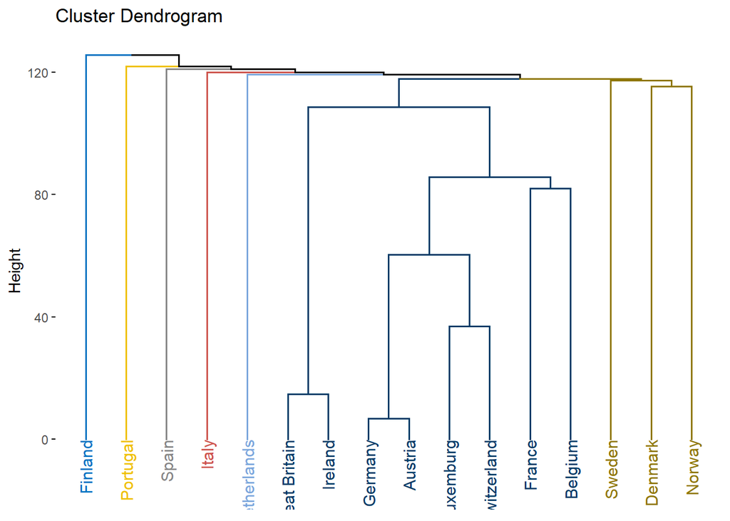

```r
hr.single.7 <- eclust(df.hc, "hclust", k = 7, hc_method="single")
fviz_dend(hr.single.7, show_labels=TRUE, palette="jco", as.ggplot=T)
```

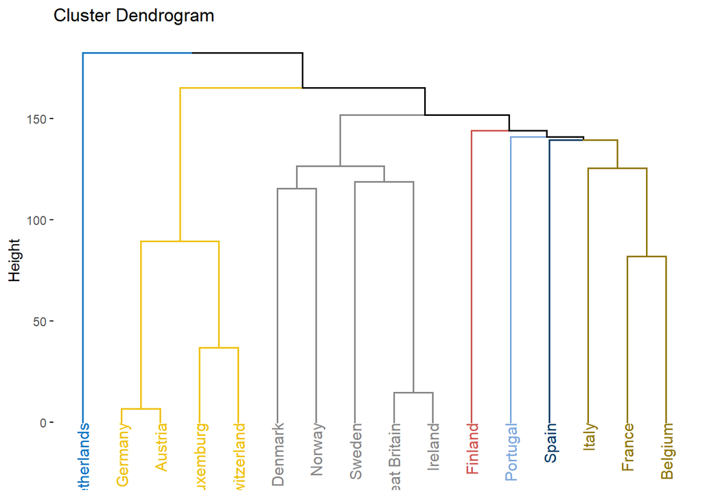

```r
hr.complete.7 <- eclust(df.hc, "hclust", k = 7, hc_method="complete")
fviz_dend(hr.complete.7, show_labels=TRUE, palette="jco", as.ggplot=T)
```

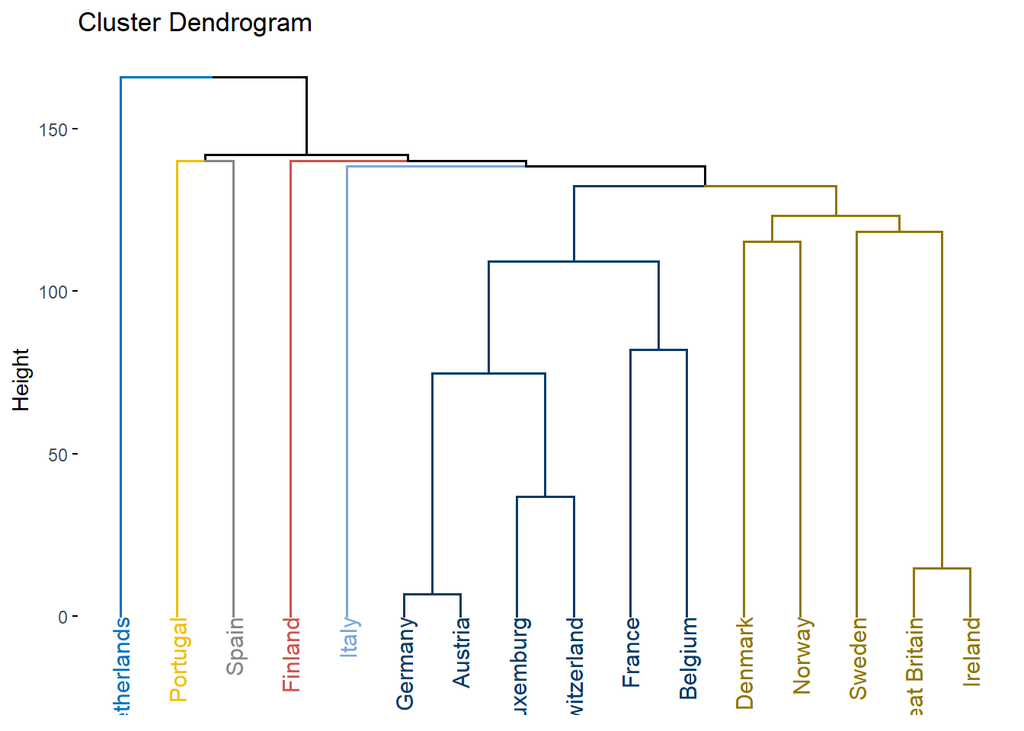

```r
hr.average.7 <- eclust(df.hc, "hclust", k = 7, hc_method="average")
fviz_dend(hr.average.7, show_labels=TRUE, palette="jco", as.ggplot=T)
```

### For each cluster obtained by the value of k used in (f), print the Dunn and Silhouette width using the fpc::cluster.stats() method. Take a look at the help (or manual) page for fpc::cluster.stats() and see what is the name of the return list component that contains the Dunn index and the average Silhouette width.

```r
library(fpc)
hr.single.7.stats <- cluster.stats(dist(df.hc),hr.single.7$cluster)
hr.single.7.stats$avg.silwidth
```

```
[1] 0.1215
```

```r
hr.single.7.stats$dunn
```

```
[1] 0.7813
```

```r
hr.complete.7.stats <- cluster.stats(dist(df.hc),hr.complete.7$cluster)
hr.complete.7.stats$avg.silwidth
```

```
[1] 0.1922
```

```r
hr.complete.7.stats$dunn
```

```
[1] 0.6769
```

```r
hr.average.7.stats <- cluster.stats(dist(df.hc),hr.average.7$cluster)
hr.average.7.stats$avg.silwidth
```

```
[1] 0.1698
```

```r
hr.average.7.stats$dunn
```

```
[1] 0.8073
```

### From the three clusters in (g), which is the best cluster obtained if you consider the Dunn index only?

### Dunn index has a value between 0 and infinity and should be maximized.Here it is maximum for average linkage method with k=7,ie : 0.8073.So I will be selecting the same considering only dunn index.

### From the three clusters in (g), which is the best cluster obtained if you consider the Silhouette width only?

### Sil.width is maximum(near to 1) for complete linkage method with k=7,ie: 0.1922.So I will be selecting this strategy if I consider only Silhouette width.

## K-Means and PCA

#### HTRU2 is a data set which describes a sample of pulsar candidates collected during an astronomical survey.More information on HTRU is provided on the UCI Machine Learning Repository (see https://archive.ics.uci.edu/ml/datasets/HTRU2). The dataset consists of 17,898 observations in 8 dimensions,with the 9 attribute being a binary class variable (0 or 1). The dataset is available to you on Blackboard; it is highly recommended that you read the UCI Machine Learning Repository link given above to get more information about the dataset.

### Perform PCA on the dataset and answer the following questions:

```r
htru2 <- read.csv(file="HTRU_2-small.csv", header=TRUE, sep=",")
htru2.pca <- prcomp(scale(htru2))
names(htru2.pca)
```

```
[1] "sdev"     "rotation" "center"   "scale"    "x"
```

```
sdev
rotation
center
scale
x
```

### How much cumulative variance is explained by the first two components?

```r
summary(htru2.pca)
```

```
Importance of components:
                         PC1   PC2    PC3    PC4    PC5    PC6    PC7     PC8     PC9
Standard deviation     2.175 1.482 0.9044 0.7103 0.5580 0.5078 0.3825 0.13199 0.12659
Proportion of Variance 0.526 0.244 0.0909 0.0561 0.0346 0.0287 0.0163 0.00194 0.00178
Cumulative Proportion  0.526 0.770 0.8607 0.9168 0.9514 0.9800 0.9963 0.99822 1.00000
```

### Plot the first two principal components. Use a different color to represent the observations in the two classes.

[figure not shown]

```r
biplot(htru2.pca,scale=0,col = c(1,5))
```

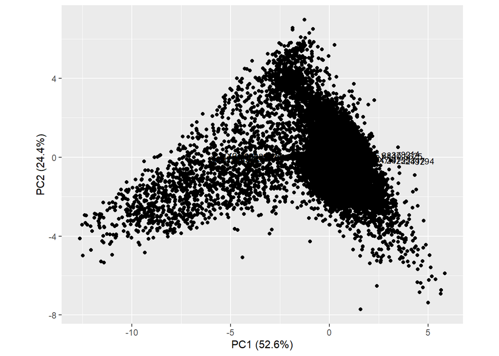

```r
if (!require(devtools)) install.packages("devtools")
if (!require(ggbiplot)) install_github("ggbiplot", "vqv")
library(ggbiplot)
ggbiplot(htru2.pca, obs.scale = 1, var.scale = 10, groups = htru2$class, ellipse = TRUE, title="Biplot for htru2 (PC1, PC2)", var.axes=TRUE)
```

### Describe what you see with respect to the actual label of the HTRU2 dataset.

```r
htru2.pca$rotation <- htru2.pca$rotation
htru2.pca$rotation
```

```
                  PC1     PC2      PC3      PC4      PC5        PC6       PC7      PC8
X140.5625      0.3527  0.3161 -0.01183 -0.13852 -0.38695 -0.7190513  0.062767  0.29140
X55.68378214   0.2093  0.3893 -0.48256  0.69499  0.28003 -0.0326011 -0.077439 -0.05724
X.0.234571412 -0.4069 -0.2704 -0.07170  0.17883  0.23394 -0.1596491 -0.079326  0.79630
X.0.699648398 -0.3882 -0.2559 -0.05391  0.03617  0.25785 -0.6643480 -0.085120 -0.51357
X3.199832776  -0.3060  0.2836 -0.53640 -0.42391  0.12806  0.0540381  0.574998  0.01046
X19.11042633  -0.3444  0.3530 -0.21956 -0.23741 -0.22470  0.0894982 -0.732856 -0.02929
X7.975531794   0.3208 -0.4474 -0.27626 -0.03239 -0.03939 -0.0004607 -0.006026 -0.05361
X74.24222492   0.2474 -0.4275 -0.57556 -0.19796 -0.13268  0.0274177 -0.224150  0.03815
X0            -0.3732 -0.1480 -0.12422  0.43383 -0.75139  0.0580887  0.241960 -0.09309
                     PC9
X140.5625     -0.0267157
X55.68378214  -0.0047022
X.0.234571412 -0.0597684
X.0.699648398  0.0279129
X3.199832776  -0.0920644
X19.11042633  -0.2362011
X7.975531794  -0.7843020
X74.24222492   0.5617084
X0            -0.0001519
```

### We know that the HTRU2 dataset has two classes. We will now use K-means on the HTRU2 dataset.

### Perform K-means clustering on the dataset with k = 2. Plot the resulting clusters.

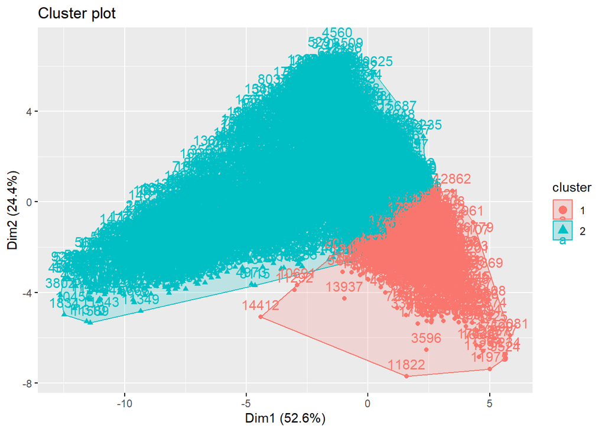

```r
htru2.km <- kmeans(htru2, centers=2, nstart=25)
fviz_cluster(htru2.km, data=htru2)
```

### Provide observations on the shape of the clusters you got in (b)(i) to the plot of the first two principal components in (a)(ii). If the clusters are are similar, why? If they are not, why?

### Clusters are not similar in PCA and in KMeans.In PCA the two clusters are along the maximum variance direction.But in KMeans its based on centroid and in each iteration centroid will move to the mean location etc.The idea of both algorithms are different.Apart from the idea of algorithms,PCA is used to reduce diamensions where as KMeans is used for clustering.We can do KMeans on large data sets after doing a PCA on the same.

### What is the distribution of the observations in each cluster?

```r
table(htru2.km$cluster)
```

```
    1     2
 2596 15301
```

### What is the distribution of the classes in the HTRU2 dataset?

```r
table(htru2$class)
```

```
< table of extent 0 >
```

### Based on the distribution of the classes in (b)(iii) and (b)(iv), which cluster do you think corresponds to the majority class and which cluster corresponds to the minority class?

### Let’s focus on the larger cluster. Get all of the observations that belong to this cluster. Then, state what is the distribution of the classes within this large cluster; i.e., how many observations in this large cluster belong to class 1 and how many belong to class 0?

```r
#for cluster 1
row.c1 <- which(htru2.km$cluster == 1)
htru.c1 <- htru2[row.c1,]
head(htru.c1)
```

|  | X140.5625 | X55.68378214 | X.0.234571412 | X.0.699648398 | X3.199832776 | X19.11042633 | X7.975531794 | X74.24222492 | X0 |
| --- | --- | --- | --- | --- | --- | --- | --- | --- | --- |
| 4 | 88.73 | 40.67 | 0.60087 | 1.1235 | 1.1789 | 11.47 | 14.27 | 252.6 | 0 |
| 6 | 119.48 | 48.77 | 0.03146 | -0.1122 | 0.9992 | 9.28 | 19.21 | 479.8 | 0 |
| 7 | 130.38 | 39.84 | -0.15832 | 0.3895 | 1.2207 | 14.38 | 13.54 | 198.2 | 0 |
| 11 | 133.26 | 44.06 | -0.08106 | 0.1154 | 1.6321 | 12.01 | 11.97 | 195.5 | 0 |
| 16 | 109.64 | 49.02 | 0.13764 | -0.2567 | 1.5084 | 12.07 | 13.37 | 223.4 | 0 |
| 30 | 110.11 | 41.32 | 0.09486 | 0.6831 | 1.0100 | 13.03 | 14.67 | 231.2 | 0 |

```r
table(htru.c1$class)
```

```
< table of extent 0 >
```

```r
#for cluster 2
row.c2 <- which(htru2.km$cluster == 2)
htru.c2 <- htru2[row.c2,]
head(htru.c2)
```

|  | X140.5625 | X55.68378214 | X.0.234571412 | X.0.699648398 | X3.199832776 | X19.11042633 | X7.975531794 | X74.24222492 | X0 |
| --- | --- | --- | --- | --- | --- | --- | --- | --- | --- |
| 1 | 102.51 | 58.88 | 0.46532 | -0.5151 | 1.677 | 14.86 | 10.576 | 127.39 | 0 |
| 2 | 103.02 | 39.34 | 0.32333 | 1.0512 | 3.121 | 21.74 | 7.736 | 63.17 | 0 |
| 3 | 136.75 | 57.18 | -0.06841 | -0.6362 | 3.643 | 20.96 | 6.896 | 53.59 | 0 |
| 5 | 93.57 | 46.70 | 0.53190 | 0.4167 | 1.636 | 14.55 | 10.622 | 131.39 | 0 |
| 8 | 107.25 | 52.63 | 0.45269 | 0.1703 | 2.332 | 14.49 | 9.001 | 107.97 | 0 |
| 9 | 107.26 | 39.50 | 0.46588 | 1.1629 | 4.079 | 24.98 | 7.397 | 57.78 | 0 |

```r
table(htru.c2$class)
```

```
< table of extent 0 >
```

### How much variance is explained by the clustering?

```r
print(htru2.km)
```

[output not shown]

### What is the average Silhouette width of both the clusters?

```r
htru2.km.stats <- cluster.stats(dist(htru2),htru2.km$cluster)
htru2.km.stats$avg.silwidth
```

```
[1] 0.5947
```

### What is the per cluster Silhouette width? Based on this, which cluster is good?

```r
htru2.km.stats$clus.avg.silwidths
```

```
     1      2
0.4125 0.6256
```

### Perform K-means on the result of the PCA you ran in (a). More specifically, perform K-means on the first two principal component score vectors (i.e., pca$x[, 1:2]). Use k = 2.

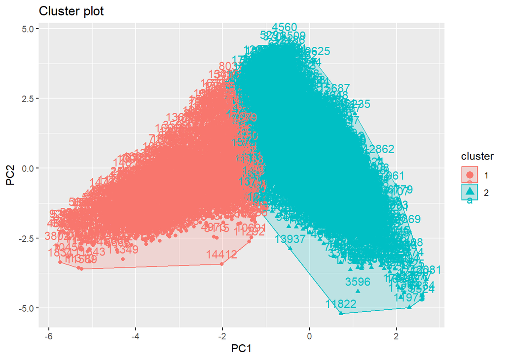

```r
htru2.kmOnPCA <- kmeans(htru2.pca$x[,1:2], centers=2, nstart=25)
fviz_cluster(htru2.kmOnPCA, data=htru2.pca$x[,1:2])
```

### Plot the clusters and comment on their shape with respect to the plots of a(ii) and b(i).

### Plot of the KMeans can be seen above.Previously the cluster boundary of cluster 1 was bit encroaching to the cluster 2,now they are divided in a fine way and this would definitely give proper balance of class 0 and 1 in between cluster 1 and cluster 2.This plot is bit closer to a(ii) and an improved version of b(i), as we performed PCA before KMeans.This improvement is because we did KMeans on after PCA(only on PC1 and PC2,which have highest variance in dataset).

### What is the average Silhouette width of both the clusters?

```r
htru2.kmOnPCA.stats <- cluster.stats(dist(htru2.pca$x[,1:2]),htru2.kmOnPCA$cluster)
htru2.kmOnPCA.stats$avg.silwidth
```

```
[1] 0.7066
```

### What is the per cluster Silhouette width? Based on this, which cluster is good?

```r
htru2.kmOnPCA.stats <- cluster.stats(dist(htru2.pca$x[,1:2]),htru2.kmOnPCA$cluster)
htru2.kmOnPCA.stats$clus.avg.silwidths
```

```
     1      2
0.4906 0.7244
```